# P5

Amalia Tsakali

2022-10-30

```r
library(MASS)
library(class)
library(ISLR)
library(tidyverse)
set.seed(45)
```

#Default dataset 1.Create a scatterplot of the Default dataset, where balance is mapped to the x position, income is mapped to the y position, and default is mapped to the colour. Can you see any interesting patterns already?

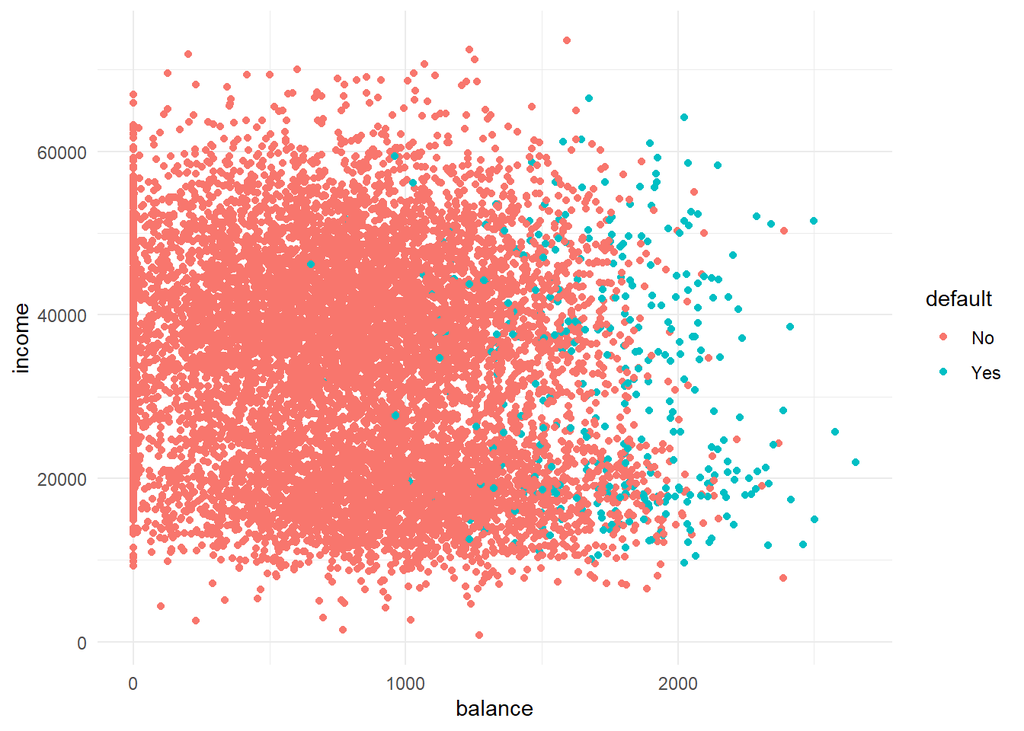

```r
Default %>% ggplot(aes(x=balance,y=income,colour = default))+geom_point()+theme_minimal()
```

```r
#default yes is seen mainly on high balance values
```

2.Add facet_grid(cols = vars(student)) to the plot. What do you see?

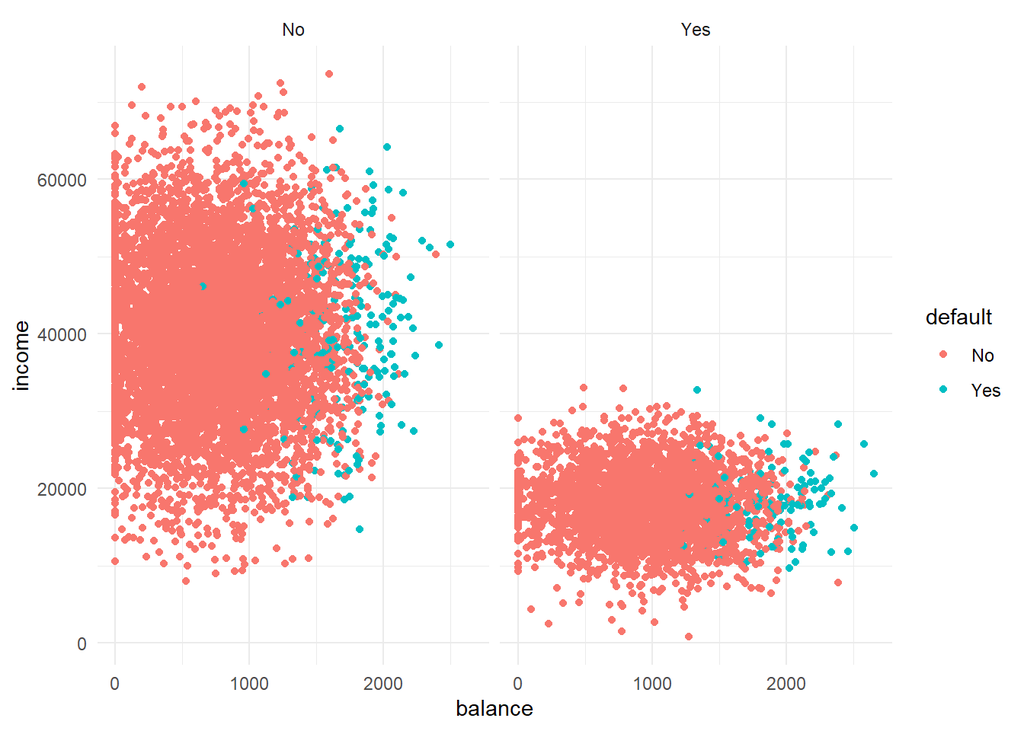

```r
Default %>% ggplot(aes(x=balance,y=income,colour = default))+geom_point()+theme_minimal()+facet_grid(cols = vars(student))
```

```r
#students make up a group with lower income
```

3.Transform “student” into a dummy variable using ifelse() (0 = not a student, 1 = student). Then, randomly split the Default dataset into a training set default_train (80%) and a test set default_test (20%)

```r
default_df<-Default %>% mutate(student= ifelse(student=="Yes",1,0)) %>% mutate(split = sample(rep(c("train", "test"), times = c(8000, 2000))))

default_train<- default_df %>% filter(split=="train") %>% select(-split)

default_test<- default_df %>% filter(split=="test") %>% select(-split)
```

##K-Nearest Neighbours

4.Create class predictions for the test set using the knn() function. Use student, balance, and income (but no basis functions of those variables) in the default_train dataset. Set k to 5. Store the predictions in a variable called knn_5_pred.

```r
knn_5_pred<-knn(train = default_train %>% select(-default),
  test  = default_test  %>% select(-default),cl=as_factor(default_train$default),k=5)
```

5.Create two scatter plots with income and balance as in the first plot you made. One with the true class (default) mapped to the colour aesthetic, and one with the predicted class (knn_5_pred) mapped to the colour aesthetic.

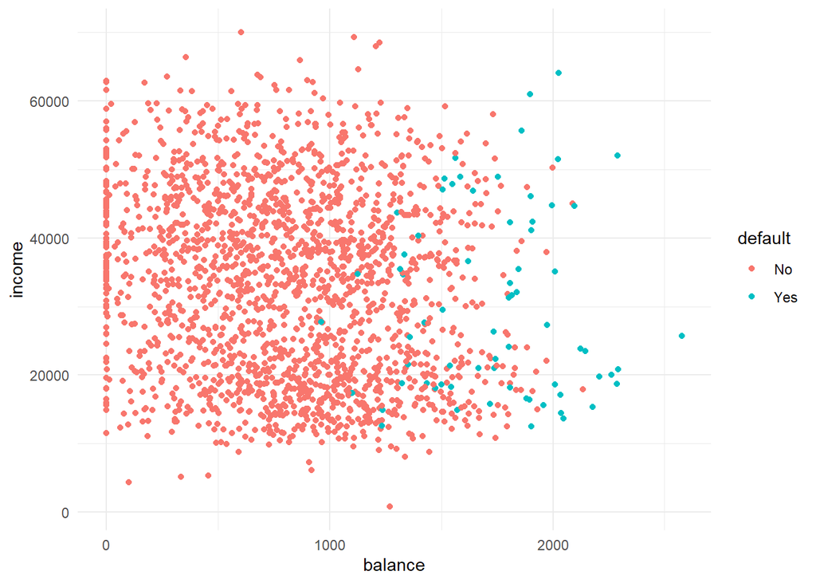

```r
default_test %>% ggplot(aes(x=balance,y=income,colour = default))+geom_point()+theme_minimal()+labs("True class")
```

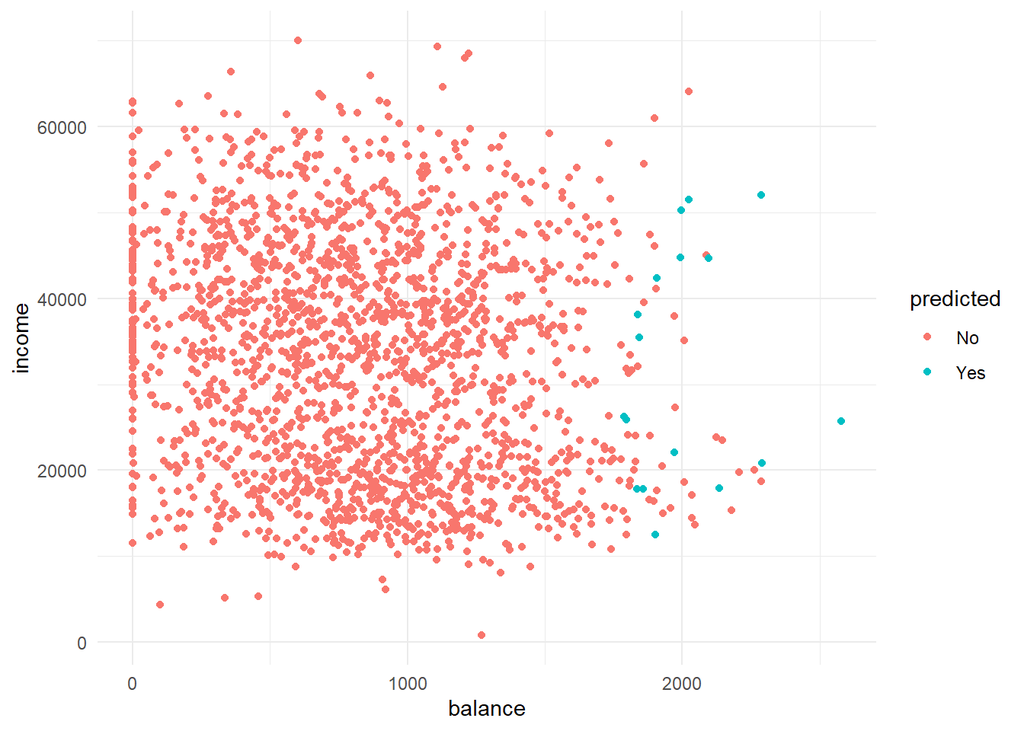

```r
data.frame(default_test,predicted=knn_5_pred) %>% ggplot(aes(x=balance,y=income,colour = predicted))+geom_point()+theme_minimal()+labs("Predicted class")
```

6.Repeat the same steps, but now with a knn_2_pred vector generated from a 2-nearest neighbours algorithm. Are there any differences?

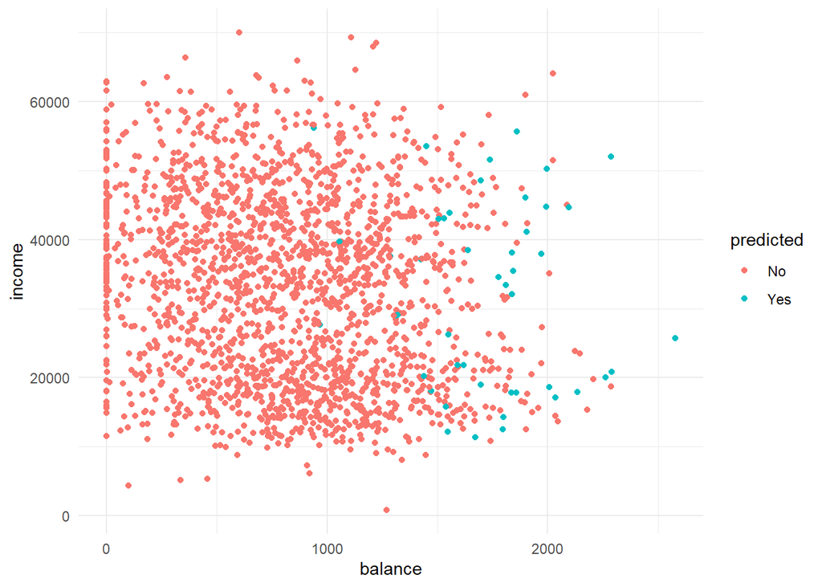

```r
knn_2_pred<-knn(train = default_train %>% select(-default),
  test  = default_test  %>% select(-default),cl=as_factor(default_train$default),k=2)

data.frame(default_test,predicted=knn_2_pred) %>% ggplot(aes(x=balance,y=income,colour = predicted))+geom_point()+theme_minimal()+labs("Predicted class")
```

```r
#more cases classified as yes than in the previous model
```

##Confusion matrix

7.What would this confusion matrix look like if the classification were perfect?

```r
table(true = default_test$default, predicted = knn_2_pred)
```

```
##      predicted
## true    No  Yes
##   No  1899   31
##   Yes   55   15
```

```r
#if it was the perfect predictive model, the values top right and bottom left would be 0
```

8.Make a confusion matrix for the 5-nn model and compare it to that of the 2-nn model. What do you conclude?

```r
table(true=default_test$default, predicted=knn_5_pred)
```

```
##      predicted
## true    No  Yes
##   No  1922    8
##   Yes   61    9
```

```r
# we see more false negatives and less false positives in this one
#we also see more true negatives but less true positives
```

##Logistic regression 9.Use glm() with argument family = binomial to fit a logistic regression model lr_mod to the default_train data.

```r
lr_mod<-glm(default ~ .,family=binomial,data = default_train)
```

10.Visualise the predicted probabilities versus observed class for the training dataset in lr_mod. You can choose for yourself which type of visualisation you would like to make. Write down your interpretations along with your plot.

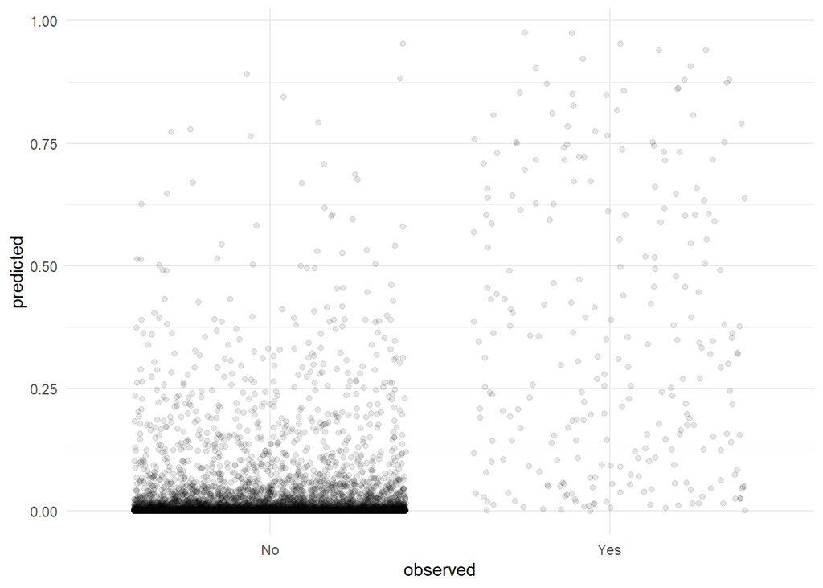

```r
tibble(observed  = default_train$default,
       predicted = predict(lr_mod, type = "response")) %>%
  ggplot(aes(x=observed, y=predicted)) +geom_jitter(alpha=0.1)+theme_minimal()
```

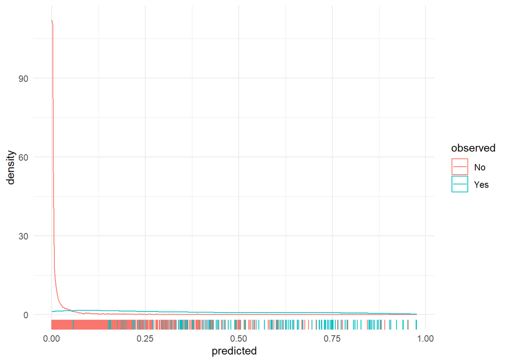

```r
#The true yes values seem to get a uniform distribution of predicted values,
#the true no values get mostly very low predicted scores but there are also some high predicted probabilities

tibble(observed  = default_train$default,
       predicted = predict(lr_mod, type = "response")) %>%
  ggplot(aes(x=predicted, colour=observed)) +geom_density(alpha=0.1)+theme_minimal()+geom_rug()
```

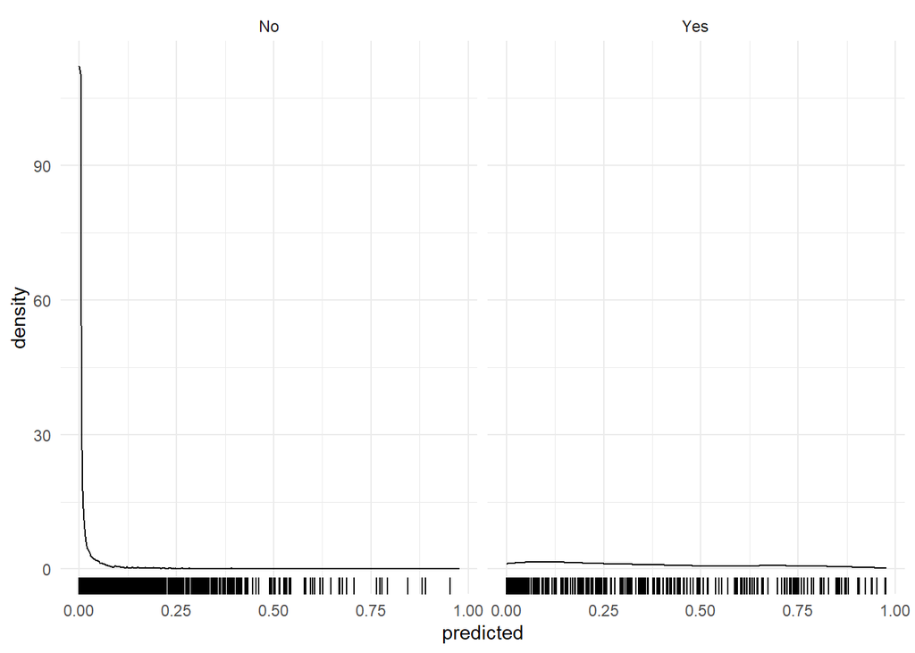

```r
tibble(observed  = default_train$default,
       predicted = predict(lr_mod, type = "response")) %>%
  ggplot(aes(x=predicted)) +geom_density()+facet_grid(cols=vars(observed))+theme_minimal()+geom_rug()
```